# DF检验临界值表模拟

齐玥3120319078

2021年3月31日

# 1 原理分析

## 1.1 四种情况简介

经济时间序列数据，特别是宏观经济数据，常常呈现明显的时间趋势，但仅从图像上无法确定数据是由*带趋势项的稳定过程*，还是由*带常数项的单位根过程*产生的。

若对带趋势的稳定过程$y_t=c+rt+u_t$中的参数$c$和$r$做t-检验，即使数据不是由确定性趋势产生的，而是由带常数项的单位根过程产生的，$t_T$统计量仍会呈显著性。

因此，在检验时间趋势之前，要先确定在时间序列中是否存在单位根。只有在单位根假设被拒绝后，才采用确定性趋势模型，并对其中的参数检验。

在情况1和情况2中，先考虑$y_t=\rho y_{t-1}+\epsilon_t$和$y_t=\alpha+\rho y_{t-1}+\epsilon_t$中，对单位根假设$H_0:\rho=1$做检验。

情况3考虑在$y_t=\alpha+\rho y_{t-1}+\epsilon_t$中检验单位根假设，此时上文中的两个统计量都有正态的极限分布，可以从正态分布和t-分布表中得到临界值，此处不进行模拟。

而情况4考虑在$y_t=\alpha+\rho y_{t-1}+\delta t+\epsilon_t$中检验单位根。

李子奈《高等计量经济学》建议：

- 按照先模型三（情况4）、再模型二（情况2）、最后模型一（情况1）。
- 先检验情况4是否有单位根，若拒绝原假设（无单位根），则检验结束；否则存在单位根，继续检验是否存在确定性趋势。
- 再检验情况2是否有单位根，若拒绝原假设（无单位根），则检验结束；否则存在单位根，继续检验是否存在漂移项。
- 最后检验情况1，若拒绝原假设，则无单位根；否则存在单位根。检验结束。

## 1.2 $T(\hat \rho_T-1)$和$t(\hat\rho)$的估计原理

为了模拟上述情况1,2和4的临界值表1和2，本文分别根据$T(\hat \rho_T-1)$和$t(\hat\rho)$的极限分布模拟足够多的统计量值（本文用10,000个），再对统计量排序根据显著性水平计算临界值。这两个非标准随机变量都可以表示成维纳过程的函数。

由泛函中心极限定理，部分和$\sqrt TX_T(r)=\frac{1}{\sqrt T}\sum_{t=1}^{T_r}\epsilon_t$弱收敛于维纳过程$B(r)$，即$\sqrt TX_T(r)\Rightarrow B(r)$，本文据此模拟维纳过程

```r
#设置全局变量，时间序列长度、显著性水平和MCMC模拟次数
T.vec <- c(25,50,100,250,500,5000)
alpha.vec <- c(0.01,0.025,0.05,0.1,0.9,0.95,0.975,0.99)
reps <- 10000

#输入用于计算统计量的维纳过程函数f(W,r)，r在情况4中用到，以及画密度图的函数；输出临界值表
getCriticalValue <- function(wienerFunction=NA,plotDensity=NA,delta.f=NA){
  table.cv <- c()#保存临界值
  table.DFstats <- c()#保存模拟的统计量
  for(T in T.vec){
    DFstats <- rep(NA,reps)
    r <- seq(0,1,length.out = T)
    for(i in 1:reps){
      if(is.na(delta.f)){
        epsilon <- rnorm(T)
        W <- 1/sqrt(T)*cumsum(epsilon)#部分和弱收敛于维纳过程
        DFstats[i] <- wienerFunction(W,r)#统计量是维纳过程的函数
      }else{
        DFstats[i] <- calcFStats(delta.f,T)#否则计算F统计量
      }
    }
    criticalValues <- sort(DFstats)[alpha.vec*reps]#排序后获取临界值
    table.cv <- rbind(table.cv, criticalValues)
    table.DFstats <- rbind(table.DFstats, DFstats)#6行reps列
  }
  plotDensity(table.cv,table.DFstats,T.vec)
  rownames(table.cv) <- as.character(T.vec)
  colnames(table.cv) <- as.character(alpha.vec)
  return(round(table.cv,2))
}

#画每个统计量和N(0,1)的密度函数图，标出5%分位数
plotDensity <- function(table.cv,table.DFstats,T.vec){
  for(i in 1:length(table.DFstats[,1])){
    data <- table.DFstats[i,]
    data.nna <- data[!is.na(data)]#情况4出现了空缺值，这里忽略掉
    plot(density(data.nna),col=c("purple"),main=paste("DF统计量密度函数(T=",T.vec[i],")"))
    xax <- seq(-4,4,by=.1)
    lines(xax,dnorm(xax),col=c("chartreuse4"))
    abline(v=table.cv[i,3])
  }
}
```

## 1.3 $F_T$的估计原理

其中，检验统计量$F_T=\frac{(\tilde R^2-\hat R^2)/2}{\hat R^2/(T-q)}$。

```r
#DGP，输入alphpa(漂移项),rho(一阶滞后项的系数),delta(确定性趋势系数),T(时长)，据此生成不同的时间序列
generateData <- function(alpha, rho, delta, T){
  yt <- rep(NA,T)
    epsilon <- rnorm(T)
    time <- seq(1,T)
    y0 <- 0
    yt[1] = alpha + rho*y0+ delta*time[1] + epsilon[1]
    for(i in 2:T){
      yt[i] = alpha + rho*yt[i-1]+ delta*time[i] + epsilon[i]
    }
    if(delta!=0){#加上确定性趋势项
      df <- cbind(yt[-T],yt[-1],time[-T])
    }
    df <- cbind(yt[-T],yt[-1])
  return(df)
}

#输入x,y和alpha（用于判断回归模型是否有截距项），输出Rss
getRss <- function(x,y,alpha=-1){
  if(alpha==0){
    model <- lm(y~x-1)
  }else{
    model <- lm(y~x)
  }
  Rss <- sum((model$fitted.values-y)^2)
  return(Rss)
}

#输入完整模型和原假设成立时的受限模型模拟的数据，以及是否有截距项，输出模拟的F统计量
getFValue <- function(dfFull, dfRestr,delta.f,alpha=-1){
  Rss.full <- getRss(dfFull[,-1],dfFull[,1])
  Rss.restr <- getRss(dfRestr[,-1],dfRestr[,1],alpha)
  T <- length(dfFull[,1])+1
  if(delta.f){
    F.value <- (Rss.restr-Rss.full)/2/(Rss.full/(T-3))
  }else{
    F.value <- (Rss.restr-Rss.full)/2/(Rss.full/(T-2))
  }
  return(round(F.value,2))
}


#输入是否情况有delta（若有delta就是情况4，否则是情况2）和T，获取相应情况下的F_T临界值表
calcFStats <- function(delta.f,T){
  rho = runif(n=1)
  if(delta.f){
    delta = rnorm(1)
    dfFull <- generateData(0, rho, delta, T)
    dfRestricted <- generateData(0, rho, 0, T)
    Fstats <- getFValue(dfFull, dfRestricted,delta.f)
  }else{
    alpha = rnorm(1)
    dfFull <- generateData(alpha, rho, 0, T)
    dfRestricted <- generateData(0, rho, 0, T)
    Fstats <- getFValue(dfFull, dfRestricted,delta.f,alpha=0)
  }
  return(Fstats)
}
```

# 2 情况一

在情况一中，所用模型为$y_t=\rho y_{t-1}+\epsilon_t$。
$$H_0: \rho=1$$
$$H_1: \rho<1$$

## 2.1 $T(\hat \rho_T-1)$模拟结果

原假设$\rho=1$成立时，表1统计量极限分布：$T(\hat \rho_T-1)=\frac{\frac 1 2[W(1)^2-1]}{\int_{0}^{1}W(r)^2dr}$.

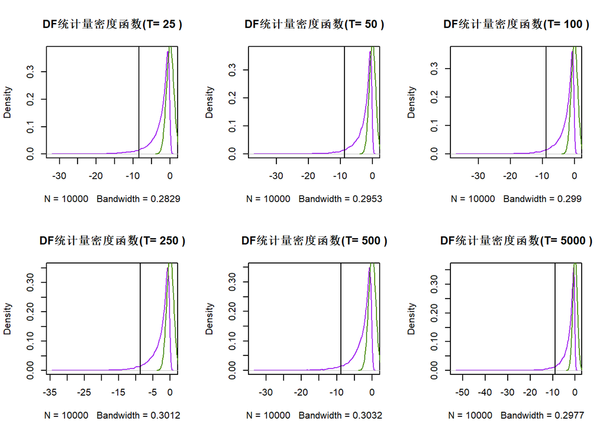

```r
subplots(nrow=2, ncol=3)
#表1情况1（无常数项）
t1s1 <-  function(W,r){
  DFstats <- (W[1]^2-1)/(2*mean(W^2))
  return(DFstats)
}
table1.s1 <- getCriticalValue(t1s1,plotDensity)
```

```r
print(table1.s1)
```

```
##        0.01  0.025  0.05   0.1   0.9  0.95 0.975  0.99
## 25   -14.07 -11.07 -8.50 -6.18 -0.39 -0.27 -0.21 -0.16
## 50   -14.97 -11.32 -8.72 -6.45 -0.41 -0.29 -0.23 -0.18
## 100  -14.54 -11.26 -8.83 -6.51 -0.41 -0.29 -0.22 -0.17
## 250  -14.48 -10.87 -8.62 -6.44 -0.42 -0.30 -0.23 -0.17
## 500  -14.26 -11.10 -8.75 -6.34 -0.42 -0.31 -0.24 -0.18
## 5000 -14.38 -11.46 -8.87 -6.48 -0.42 -0.30 -0.24 -0.18
```

## 2.2 $t(\hat\rho)$模拟结果

原假设$\rho=1$成立时，表2统计量极限分布$t(\hat\rho)=\frac{\hat \rho_T-1}{s(\hat\rho)}=\frac{\frac 1 2 [W(1)^2-1]}{(\int_{0}^{1}W(r)^2dr)^\frac 1 2}$.

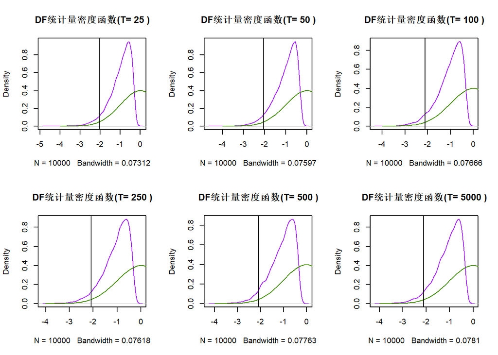

```r
subplots(nrow=2, ncol=3)
#表2情况1（无常数项）
t2s1 <-  function(W,r){
  DFstats <- (W[1]^2-1)/(2*sqrt(mean(W^2)))
  return(DFstats)
}
table2.s1 <- getCriticalValue(t2s1,plotDensity)
```

```r
print(table2.s1)
```

```
##       0.01 0.025  0.05   0.1   0.9  0.95 0.975  0.99
## 25   -2.65 -2.33 -2.03 -1.72 -0.42 -0.36 -0.31 -0.27
## 50   -2.64 -2.32 -2.06 -1.77 -0.44 -0.38 -0.33 -0.29
## 100  -2.70 -2.37 -2.11 -1.81 -0.45 -0.38 -0.33 -0.29
## 250  -2.66 -2.36 -2.08 -1.79 -0.45 -0.38 -0.34 -0.30
## 500  -2.67 -2.33 -2.08 -1.84 -0.46 -0.39 -0.35 -0.31
## 5000 -2.72 -2.40 -2.11 -1.83 -0.46 -0.40 -0.35 -0.30
```

# 3 情况二

在情况二中，所用模型为$y_t=\alpha+\rho y_{t-1}+\epsilon_t$。
$$H_0: \alpha=0,\rho=1$$
$$H_1: \alpha\ne0,\rho<1$$

## 3.1 $T(\hat \rho_T-1)$模拟结果

原假设$\alpha=0,\rho=1$成立时，表1统计量极限分布：$T(\hat \rho_T-1)=\frac{\frac 1 2(W^2(1)-1)-W(1)\int_0^1W(r)dr}{\int_0^1W^2(r)dr-(\int_0^1W(r)dr)^2}$.

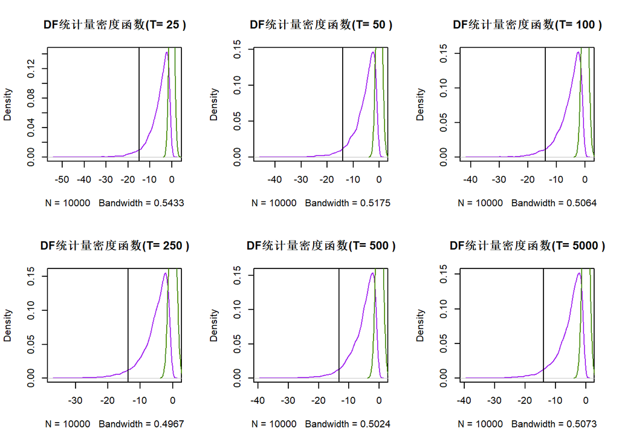

```r
subplots(nrow=2, ncol=3)
#表1情况2（有常数项）
t1s2 <-  function(W,r){
  DFstats <- ((W[1]^2-1)/2-W[1]*mean(W))/(mean(W^2)-mean(W)^2)
  return(DFstats)
}
table1.s2 <- getCriticalValue(t1s2,plotDensity)
```

```r
print(table1.s2)
```

```
##        0.01  0.025   0.05    0.1   0.9  0.95 0.975  0.99
## 25   -21.91 -18.12 -14.88 -11.52 -1.39 -0.99 -0.70 -0.47
## 50   -21.34 -17.20 -13.99 -11.15 -1.44 -1.05 -0.79 -0.56
## 100  -19.90 -16.54 -13.93 -10.91 -1.43 -1.05 -0.82 -0.61
## 250  -20.12 -16.63 -13.73 -10.81 -1.44 -1.06 -0.83 -0.63
## 500  -19.54 -15.94 -13.26 -10.66 -1.47 -1.11 -0.88 -0.66
## 5000 -20.35 -16.68 -13.92 -11.01 -1.44 -1.08 -0.87 -0.67
```

## 3.2 $t(\hat\rho)$模拟结果

原假设$\alpha=0,\rho=1$成立时，表2统计量极限分布$t(\hat\rho)=\frac{\frac 1 2(W^2(1)-1)-W(1)\int_0^1W(r)dr}{(\int_0^1W^2(r)dr-(\int_0^1W(r)dr)^2)^\frac 1 2}$.

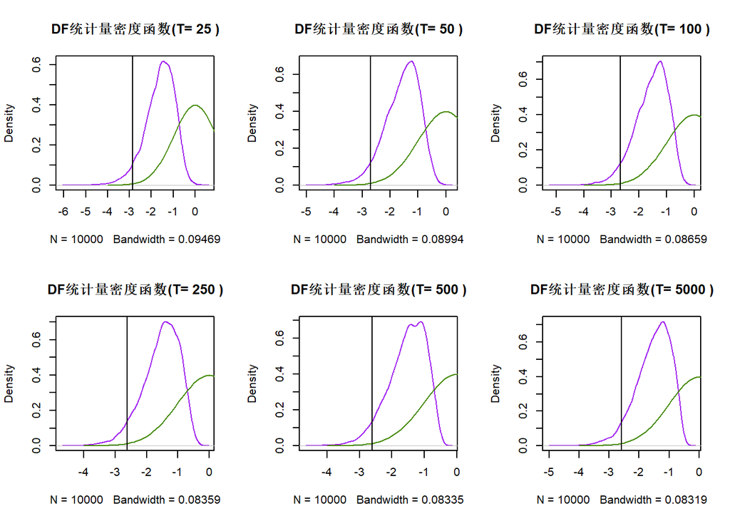

```r
subplots(nrow=2, ncol=3)
#表2情况2（有常数项）
t2s2 <-  function(W,r){
  DFstats <- ((W[1]^2-1)/2-W[1]*mean(W))/sqrt(mean(W^2)-mean(W)^2)
  return(DFstats)
}
table2.s2 <- getCriticalValue(t2s2,plotDensity)
```

```r
print(table2.s2)
```

```
##       0.01 0.025  0.05   0.1   0.9  0.95 0.975  0.99
## 25   -3.57 -3.19 -2.85 -2.51 -0.81 -0.65 -0.51 -0.35
## 50   -3.38 -2.99 -2.71 -2.41 -0.83 -0.69 -0.57 -0.45
## 100  -3.26 -2.91 -2.66 -2.37 -0.83 -0.71 -0.61 -0.51
## 250  -3.22 -2.88 -2.62 -2.35 -0.84 -0.71 -0.63 -0.54
## 500  -3.16 -2.85 -2.62 -2.34 -0.85 -0.73 -0.65 -0.57
## 5000 -3.21 -2.86 -2.59 -2.32 -0.84 -0.73 -0.66 -0.58
```

## 3.3 $F_T$模拟结果

在$F$检验时，原假设为$\alpha=0$。

当原假设成立时（即不存在漂移项），模型变为$y_t=\rho y_{t-1}+\epsilon_t$，此时$\tilde R^2=\sum_{t=1}^T(y_t-\rho y_{t-1})^2$。

当备择假设成立时（即存在漂移项），模型变为$y_t=\alpha+\rho y_{t-1}+\epsilon_t$，此时$\hat R^2=\sum_{t=1}^T(y_t-\alpha-\rho y_{t-1})^2$。

检验统计量$F_T=\frac{(\tilde R^2-\hat R^2)/2}{\hat R^2/(T-2)}$。

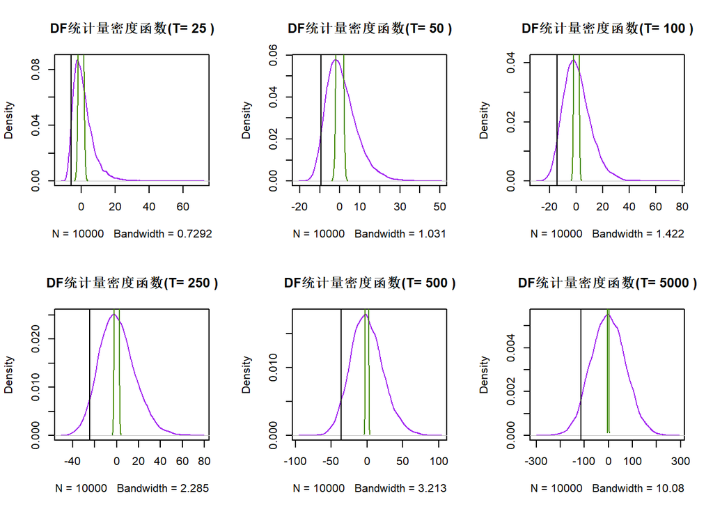

```r
subplots(nrow=2, ncol=3)
#表3情况2（有常数项和趋势项）
table3.s2 <- getCriticalValue(delta.f=F)
```

```r
print(table3.s2)
```

```
##         0.01   0.025    0.05    0.1   0.9   0.95  0.975   0.99
## 25     -7.30   -6.61   -5.89  -4.90  8.73  12.21  15.84  21.15
## 50    -12.22  -10.70   -9.31  -7.57 11.11  14.98  18.91  23.24
## 100   -18.96  -16.49  -14.35 -11.66 14.29  19.02  23.61  29.17
## 250   -33.23  -28.45  -24.34 -19.17 21.74  28.47  34.58  42.50
## 500   -48.71  -41.12  -35.87 -28.08 29.10  39.16  47.77  57.82
## 5000 -158.43 -137.25 -114.77 -91.43 90.95 115.05 140.57 164.67
```

# 4 情况四

在情况四中，所用模型为$y_t=\alpha+\rho y_{t-1}+\delta t+\epsilon_t$。
$$H_0:\delta=0,\rho=1$$
$$H_1:\delta\ne0,\rho\lt1$$

## 4.1 $T(\hat \rho_T-1)$模拟结果

原假设$\delta=0,\rho=1$成立时，表1统计量极限分布：$T(\hat \rho_T-1)=\frac 1 {|A|}\{\frac 1 6 W(1)\int_0^1W(r)dr-\frac 1 2 W(1)\int_0^1rW(r)dr+\frac 1 {24}(W^2(1)-1)+\int_0^1W(r)dr\int_0^1rW(r)dr-\frac 1 2(\int_0^1 W(r)dr)^2\}$.

其中$A=\left(\begin{array}\\ 1 & \int_0^1W(r)dr & \frac 1 2\\ \int_0^1W(r)dr & \int_0^1W^2(r)dr & \int_0^1rW(r)dr\\ \frac 1 2 & \int_0^1rW(r)dr & \frac 1 3\\ \end{array}\right)$.（陆懋祖，1999，p75-76）

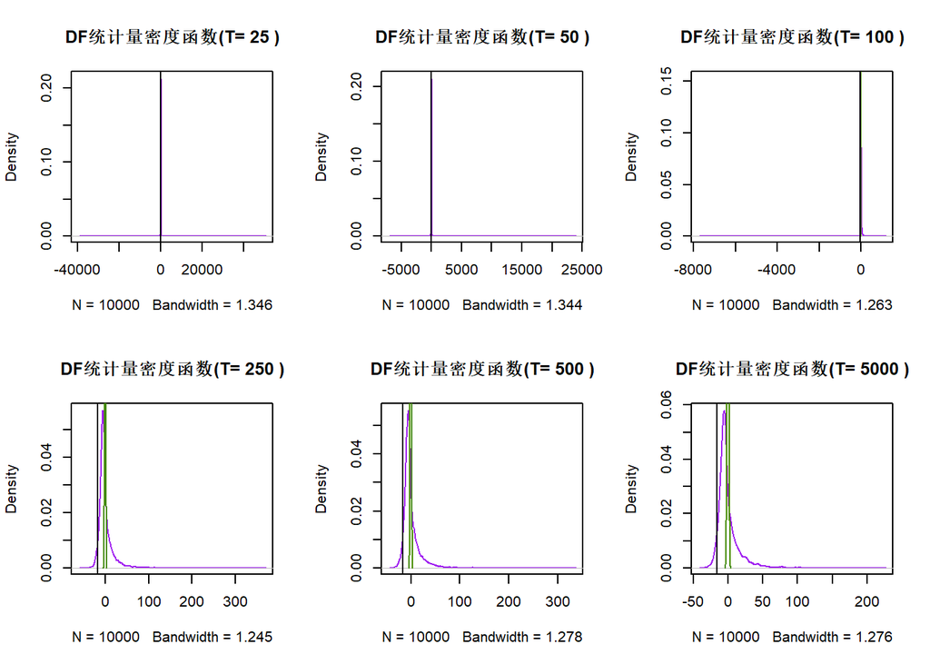

```r
subplots(nrow=2, ncol=3)
#表1情况4（有常数项和趋势项）
t1s4 <- function(W,r){
  A <- matrix(c(1,mean(W),1/2,mean(W),mean(W^2),mean(r*W),1/2,mean(r*W),1/3),nrow=3)
  DFstats <- 1/det(A)*(1/6*W[1]*mean(W)-1/2*W[1]*mean(r*W)+1/24*(W[1]^2-1)+mean(W)*mean(r*W)-1/2*mean(W)^2)
  return(DFstats)
}
table1.s4 <- getCriticalValue(t1s4,plotDensity)
```

```r
print(table1.s4)
```

```
##         0.01  0.025   0.05    0.1   0.9  0.95 0.975   0.99
## 25   -280.74 -33.07 -22.42 -16.45 22.19 51.89 99.68 228.02
## 50    -26.38 -21.19 -17.69 -14.28 22.02 43.55 81.02 181.42
## 100   -25.46 -20.68 -17.26 -13.78 19.98 38.30 63.02 100.64
## 250   -24.06 -20.00 -16.93 -13.43 18.01 32.57 51.78  85.27
## 500   -24.27 -19.92 -16.80 -13.47 18.18 32.65 49.06  77.45
## 5000  -23.03 -19.23 -16.18 -13.22 17.51 29.93 45.20  72.65
```

## 4.2 $t(\hat\rho)$模拟结果

原假设$\delta=0,\rho=1$成立时，表2统计量极限分布:$t(\hat\rho)=\frac{\sqrt3}{12}|A|^{-\frac{1}{2}}\{4 W(1)\int_0^1W(r)dr-12W(1)\int_0^1rW(r)dr+(W^2(1)-1)+24\int_0^1W(r)dr\int_0^1rW(r)dr-12(\int_0^1 W(r)dr)^2\}$. 矩阵A同上。

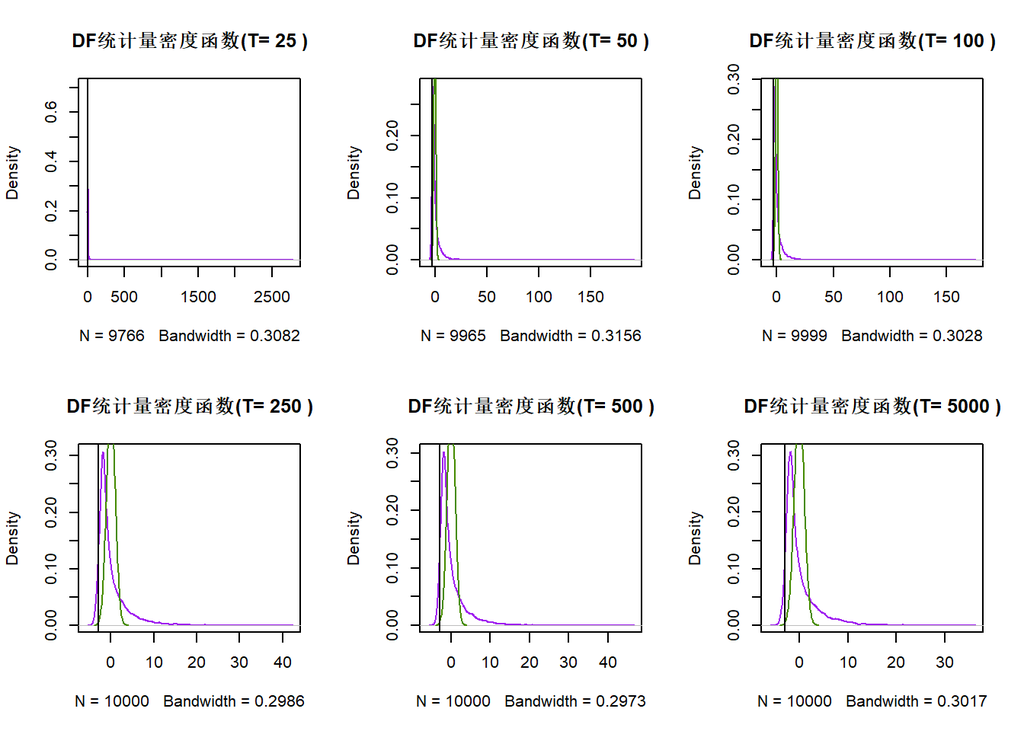

```r
subplots(nrow=2, ncol=3)
#表2情况4（有常数项和趋势项）
t2s4 <- function(W,r){
  A <- matrix(c(1,mean(W),1/2,mean(W),mean(W^2),mean(r*W),1/2,mean(r*W),1/3),nrow=3)
  DFstats <- sqrt(3)/12*(det(A))^(-1/2)*(4*W[1]*mean(W)-12*W[1]*mean(r*W)+(W[1]^2-1)+24*mean(W)*mean(r*W)-12*mean(W)^2)
  return(DFstats)
}
table2.s4 <- getCriticalValue(t2s4,plotDensity)
```

```r
print(table2.s4)
```

```
##       0.01 0.025  0.05   0.1  0.9  0.95 0.975  0.99
## 25   -3.84 -3.47 -3.13 -2.74 5.59 12.32 60.56    NA
## 50   -3.72 -3.36 -3.05 -2.69 4.76  8.19 12.39 22.73
## 100  -3.61 -3.24 -2.93 -2.64 4.40  7.75 11.35 17.00
## 250  -3.55 -3.25 -2.96 -2.61 4.10  7.00 10.05 14.78
## 500  -3.53 -3.21 -2.91 -2.60 4.02  6.79  9.94 14.43
## 5000 -3.58 -3.21 -2.93 -2.61 4.19  7.12  9.67 13.78
```

## 4.3 $F_T$模拟结果

在$F$检验时，原假设为$\delta=0$。

当原假设成立时（即不存在确定性趋势），模型变为$y_t=\alpha+\rho y_{t-1}+\epsilon_t$，此时$\tilde R^2=\sum_{t=1}^T(y_t-\alpha-\rho y_{t-1})^2$。

当备择假设成立时（即存在确定性趋势），模型变为$y_t=\alpha+\rho y_{t-1}+\delta t+\epsilon_t$，此时$\hat R^2=\sum_{t=1}^T(y_t-\alpha-\rho y_{t-1}-\delta t)^2$。

检验统计量$F_T=\frac{(\tilde R^2-\hat R^2)/2}{\hat R^2/(T-3)}$。

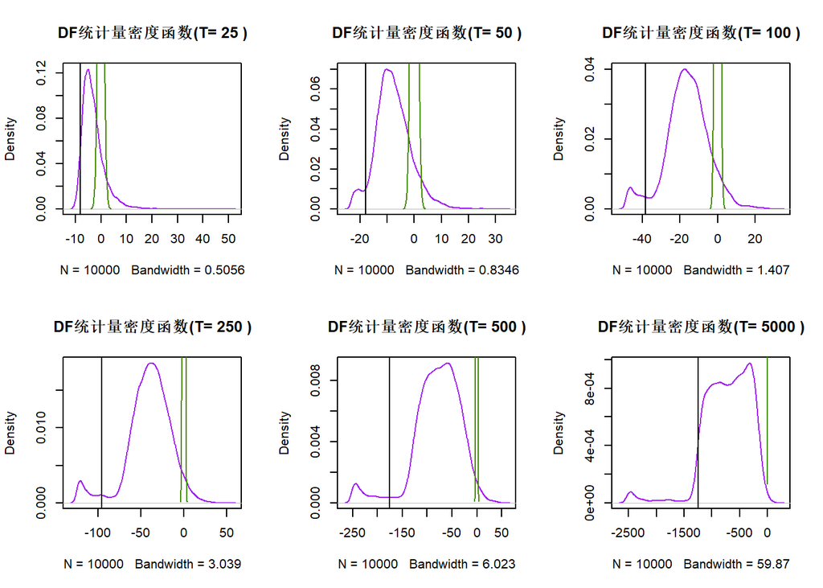

```r
subplots(nrow=2, ncol=3)
#表3情况4（有常数项和趋势项）
table3.s4 <- getCriticalValue(delta.f=T)
```

```r
print(table3.s4)
```

```
##          0.01    0.025     0.05      0.1     0.9    0.95   0.975   0.99
## 25      -9.38    -8.74    -8.16    -7.40    2.26    4.94    7.70  11.67
## 50     -22.21   -20.64   -17.88   -15.02    0.54    3.56    6.59  10.60
## 100    -47.15   -44.81   -38.40   -28.79   -2.42    1.97    5.91  11.15
## 250   -121.98  -117.02   -95.78   -66.61  -11.52   -3.75    3.07  11.45
## 500   -246.18  -231.71  -175.84  -126.63  -26.06  -14.76   -4.68   7.38
## 5000 -2441.36 -1776.61 -1244.83 -1167.09 -241.44 -180.67 -132.07 -75.90
```

# 5 结论和不足

本文根据极限分布模拟了$T(\hat \rho_T-1)$和$t(\hat\rho)$的临界值表1和2。由于不知道$F_T$统计量的具体极限分布（维纳过程的泛函），无法根据分布模拟临界值表。于是本文模拟$y_t$，用回归分析的方法计算得到限制和非限制模型下的残差平方和，并据此构造统计量$F_T$。

但本文模拟的三张表与《高等时间序列计量经济学》书中的表格有差距。对于$T(\hat \rho_T-1)$和$t(\hat\rho)$临界值表的模拟，可能是用部分和近似维纳过程的时候与原文方法有出入；而对于$F_T$临界值表的模拟，可能是由于初始化$y_0, \alpha, \rho, \delta$的方式与原文不同。

三张临界值表结果如下：

```r
#表1
rbind(table1.s1, table1.s2, table1.s4)
```

```
##         0.01  0.025   0.05    0.1   0.9  0.95 0.975   0.99
## 25    -14.07 -11.07  -8.50  -6.18 -0.39 -0.27 -0.21  -0.16
## 50    -14.97 -11.32  -8.72  -6.45 -0.41 -0.29 -0.23  -0.18
## 100   -14.54 -11.26  -8.83  -6.51 -0.41 -0.29 -0.22  -0.17
## 250   -14.48 -10.87  -8.62  -6.44 -0.42 -0.30 -0.23  -0.17
## 500   -14.26 -11.10  -8.75  -6.34 -0.42 -0.31 -0.24  -0.18
## 5000  -14.38 -11.46  -8.87  -6.48 -0.42 -0.30 -0.24  -0.18
## 25    -21.91 -18.12 -14.88 -11.52 -1.39 -0.99 -0.70  -0.47
## 50    -21.34 -17.20 -13.99 -11.15 -1.44 -1.05 -0.79  -0.56
## 100   -19.90 -16.54 -13.93 -10.91 -1.43 -1.05 -0.82  -0.61
## 250   -20.12 -16.63 -13.73 -10.81 -1.44 -1.06 -0.83  -0.63
## 500   -19.54 -15.94 -13.26 -10.66 -1.47 -1.11 -0.88  -0.66
## 5000  -20.35 -16.68 -13.92 -11.01 -1.44 -1.08 -0.87  -0.67
## 25   -280.74 -33.07 -22.42 -16.45 22.19 51.89 99.68 228.02
## 50    -26.38 -21.19 -17.69 -14.28 22.02 43.55 81.02 181.42
## 100   -25.46 -20.68 -17.26 -13.78 19.98 38.30 63.02 100.64
## 250   -24.06 -20.00 -16.93 -13.43 18.01 32.57 51.78  85.27
## 500   -24.27 -19.92 -16.80 -13.47 18.18 32.65 49.06  77.45
## 5000  -23.03 -19.23 -16.18 -13.22 17.51 29.93 45.20  72.65
```

```r
#表2
rbind(table2.s1, table2.s2, table2.s4)
```

```
##       0.01 0.025  0.05   0.1   0.9  0.95 0.975  0.99
## 25   -2.65 -2.33 -2.03 -1.72 -0.42 -0.36 -0.31 -0.27
## 50   -2.64 -2.32 -2.06 -1.77 -0.44 -0.38 -0.33 -0.29
## 100  -2.70 -2.37 -2.11 -1.81 -0.45 -0.38 -0.33 -0.29
## 250  -2.66 -2.36 -2.08 -1.79 -0.45 -0.38 -0.34 -0.30
## 500  -2.67 -2.33 -2.08 -1.84 -0.46 -0.39 -0.35 -0.31
## 5000 -2.72 -2.40 -2.11 -1.83 -0.46 -0.40 -0.35 -0.30
## 25   -3.57 -3.19 -2.85 -2.51 -0.81 -0.65 -0.51 -0.35
## 50   -3.38 -2.99 -2.71 -2.41 -0.83 -0.69 -0.57 -0.45
## 100  -3.26 -2.91 -2.66 -2.37 -0.83 -0.71 -0.61 -0.51
## 250  -3.22 -2.88 -2.62 -2.35 -0.84 -0.71 -0.63 -0.54
## 500  -3.16 -2.85 -2.62 -2.34 -0.85 -0.73 -0.65 -0.57
## 5000 -3.21 -2.86 -2.59 -2.32 -0.84 -0.73 -0.66 -0.58
## 25   -3.84 -3.47 -3.13 -2.74  5.59 12.32 60.56    NA
## 50   -3.72 -3.36 -3.05 -2.69  4.76  8.19 12.39 22.73
## 100  -3.61 -3.24 -2.93 -2.64  4.40  7.75 11.35 17.00
## 250  -3.55 -3.25 -2.96 -2.61  4.10  7.00 10.05 14.78
## 500  -3.53 -3.21 -2.91 -2.60  4.02  6.79  9.94 14.43
## 5000 -3.58 -3.21 -2.93 -2.61  4.19  7.12  9.67 13.78
```

```r
#表3
rbind(table3.s2,table3.s4)
```

```
##          0.01    0.025     0.05      0.1     0.9    0.95   0.975   0.99
## 25      -7.30    -6.61    -5.89    -4.90    8.73   12.21   15.84  21.15
## 50     -12.22   -10.70    -9.31    -7.57   11.11   14.98   18.91  23.24
## 100    -18.96   -16.49   -14.35   -11.66   14.29   19.02   23.61  29.17
## 250    -33.23   -28.45   -24.34   -19.17   21.74   28.47   34.58  42.50
## 500    -48.71   -41.12   -35.87   -28.08   29.10   39.16   47.77  57.82
## 5000  -158.43  -137.25  -114.77   -91.43   90.95  115.05  140.57 164.67
## 25      -9.38    -8.74    -8.16    -7.40    2.26    4.94    7.70  11.67
## 50     -22.21   -20.64   -17.88   -15.02    0.54    3.56    6.59  10.60
## 100    -47.15   -44.81   -38.40   -28.79   -2.42    1.97    5.91  11.15
## 250   -121.98  -117.02   -95.78   -66.61  -11.52   -3.75    3.07  11.45
## 500   -246.18  -231.71  -175.84  -126.63  -26.06  -14.76   -4.68   7.38
## 5000 -2441.36 -1776.61 -1244.83 -1167.09 -241.44 -180.67 -132.07 -75.90
```

参考资料

[1] 陆懋祖. (1999) 高等时间序列计量经济学. 上海: 上海人民出版社.